# Logistic Regression

This notebook covers the basics of logisgtic regression and its implementation from scratch in Python.

## Table of Content

1. Theory  
2. Implementation in Python  
3. Data  
4. Simple Logistic Regression  
5. Conclusion

```python
# load libraries
import numpy as np
import pandas as pd

# personal tools
import TAD_tools

# data generator and data manipulation
from sklearn.datasets import make_classification, make_blobs, make_moons,make_circles
from sklearn.model_selection import train_test_split
from sklearn.metrics import accuracy_score, confusion_matrix

# plotting tools
import matplotlib.pyplot as plt
import seaborn as sns
plt.style.use('ggplot')
%matplotlib inline
```

## 1. Theory

The idea behind the logistic regression is to build a linear model (similar to a simple linear regression) in order to predict a binary outcome (0 or 1).

In order to implement a logistic regresssion, two functions are needed. The first one is a simple linear function ($L$) coupled with the sigmoid function ($\sigma$). They are defined as:

$L(x) = b + \sum_{n=1}^{N} w_{n} * x_{n} $

and

$\sigma(x) = \frac{1}{1+e^{-x}}$

Before we dive deeper into these notions, let's define a few notations:

1. The $w$'s are called the **weights** of the model. The $b$ is commonly called the bias.
2. The input example $x$ is a n-dimension vector.

The input for our model are defined as:

1. A set of $m$ examples $\{x_{1},...,x_{m}\}$
2. A set of $m$ targets $\{y_{1},...,y_{m}\}$ where $y_{i}=0\ or\ 1$

The goal is to find the $\beta$ of the linear function is order to make the best predictions. A prediction is defined as:

$a = \sigma(z)\ where\ z=b + \sum_{n=1}^{N} w_{n} * x_{n}$

Indeed the output of the sigmoid function can be interpreted as the probability of the prediction to be either 0 or 1. In order to visualize it, let's plot the sigmoid function.

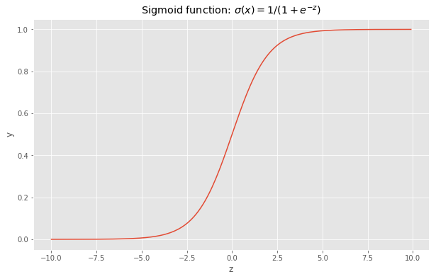

```python
# create sigmoid function
z = np.arange(-10,10,0.1)
y = 1 / (1+np.exp(-z))

# plot sigmoid
fig, ax = plt.subplots(figsize=(10,6))

ax.plot(z,y)
ax.set_xlabel('z')
ax.set_ylabel('y')
ax.set_title('Sigmoid function: $\sigma(x)=1/(1+e^{-z})$');
```

The signoid function is defined on the entiere range of real numbers and takes values in [0,1]. Therefore, if the output of the linear function is a large value, then the sigmoid will be close to 1 and close to 0 if z is very small. There is one missing aspect to our model. The goal is to predict wether y is equal to 0 or 1, to do so, we will define a threshold.

$$y_{pred}=0\ if\ a<0.5$$$$y_{pred}=1\ if\ a\geq0.5$$

Finally, we need to define a performance metric in order to assess how well our model behaves. We call this metric the **Loss Function**. It represents how close are out predictions to the actual values. The loss function is defined as:

$$\mathcal{L(x)}=-log(a)*y-log(1-a)*(1-y)$$

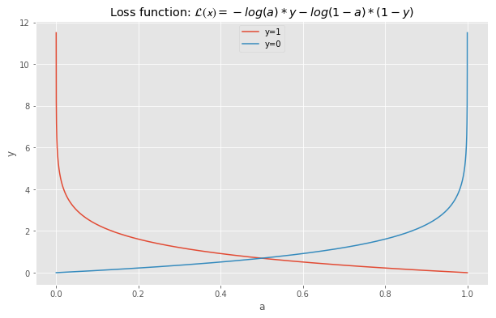

```python
# create sigmoid function
x = np.arange(0.00001,0.999999,0.00001)
y_1 = -np.log(x)
y_2 = -np.log(1-x)

# plot sigmoid
fig, ax = plt.subplots(figsize=(10,6))

ax.plot(x,y_1,label="y=1")
ax.plot(x,y_2,label="y=0")
ax.set_xlabel('a')
ax.set_ylabel('y')
ax.set_title('Loss function: $\mathcal{L(x)}=-log(a)*y-log(1-a)*(1-y)$')
ax.legend();
```

From the above plot, we see that the penalty becomes extremely large is the prediction is incorrect. For instance, if y=0 and $y_{prob}=0.95$, then the loss is equal to:

```python
-np.log(1-0.95)
```

```
2.99573227355399
```

Whereas if y=0 and $y_{prob}=0.05$, then the loss is equal to:

```python
-np.log(1-0.05)
```

```
0.05129329438755058
```

Finally, we define the **Cost Function** as the average of the **Loss Function** over the entire set of examples.

$$ J = \frac{1}{m} \sum_{i=1}^m \mathcal{L}(a^{(i)}, y^{(i)})$$

The last step of this section consists of the optimization step. Now that the model and the performance metric have been defined, the weights of the model need to be optimized in order to best fit the data. This is where the **gradient descent** comes into play. The idea behind the optimization is to look at how the performance varies as a function of the weights. To do so, the partial derivatives (slops) of the **Cost Function** are computed.

$$ \frac{\partial J}{\partial w_{i}}\ and\ \frac{\partial J}{\partial b}$$

Each parameter is then updated using:

$$ \theta_{i} = w_{i} - \alpha*\frac{\partial J}{\partial \theta{i}}$$

Where $\alpha$ is a constant called **learning** rate.

Based on our definition of the loss, we have:

$$ \frac{\partial J}{\partial w} = \frac{1}{m}X(A-Y)^T$$$$ \frac{\partial J}{\partial b} = \frac{1}{m} \sum_{i=1}^m (a^{(i)}-y^{(i)})$$

Based on the formulas presented above, it is necessary to obtain A (vector of predicted probabilities) in order to obtain the gradients. Therefore, the optimization is before as a two step process:

1. Forward propagation: Make predictions using current parameters and compute cost
2. Backward propagation: Use predictions to compute gradients and update parameters

## 2. Implementation in Python

The functions below are used to define the logistic regression model. They are defined as follows:

1. `sigmoid`: Simple mathematical function used to apply the sigmoid function to a number or an array.
2. `initialize_with_zeros`: Creates a vector of zeros of shape (dim, 1) for w and initializes b to 0
3. `propagate`: Computes the cost function and its gradient for the forward propagation
4. `optimize`: Optimizes w and b by running a gradient descent algorithm
5. `predict`: Makes a prediction based on a given input
6. `model`: Builds the logistic regression model

```python
def sigmoid(z):
    """
    Compute the sigmoid of z

    Arguments:
    z -- A scalar or numpy array of any size.

    Return:
    s -- sigmoid(z)
    """

    s = 1 / (1 + np.exp(-z))

    return s
```

```python
def initialize_with_zeros(dim):
    """
    This function creates a vector of zeros of shape (dim, 1) for w and initializes b to 0.

    Argument:
    dim -- size of the w vector we want (or number of parameters in this case)

    Returns:
    w -- initialized vector of shape (dim, 1)
    b -- initialized scalar (corresponds to the bias)
    """

    w = np.zeros(shape=(dim,1))
    b = 0.0

    assert(w.shape == (dim, 1))
    assert(isinstance(b, float) or isinstance(b, int))

    return w, b
```

```python
def propagate(w, b, X, Y):
    """
    Computes the cost function and its gradient for the forward propagation

    Arguments:
    w -- weights, a numpy array of size (num_px * num_px * 3, 1)
    b -- bias, a scalar
    X -- data of size (num_px * num_px * 3, number of examples)
    Y -- true "label" vector (containing 0 if non-cat, 1 if cat) of size (1, number of examples)

    Return:
    cost -- negative log-likelihood cost for logistic regression
    dw -- gradient of the loss with respect to w, thus same shape as w
    db -- gradient of the loss with respect to b, thus same shape as b
    """

    m = X.shape[1]                              # number of features

    # FORWARD PROPAGATION (FROM X TO COST)
    A = sigmoid(np.dot(w.T,X)+b)                                    # compute activation SHAPE (1, number of examples)
    cost = (-1/m) * np.sum( Y * np.log(A) + (1-Y) * np.log(1-A) )   # compute cost

    # BACKWARD PROPAGATION (TO FIND GRAD)
    dw = (1/m) * np.dot(X, (A-Y).T)                                 # (m,num) * (1,num).T = (m,1)
    db = (1/m) * (np.sum(A-Y))                                      # (1)

    assert(dw.shape == w.shape)
    assert(db.dtype == float)
    cost = np.squeeze(cost)
    assert(cost.shape == ())

    grads = {"dw": dw,
             "db": db}

    return grads, cost
```

```python
def optimize(w, b, X, Y, num_iterations, learning_rate, print_cost = False):
    """
    This function optimizes w and b by running a gradient descent algorithm

    Arguments:
    w -- weights, a numpy array of size (num_px * num_px * 3, 1)
    b -- bias, a scalar
    X -- data of shape (num_px * num_px * 3, number of examples)
    Y -- true "label" vector (containing 0 if non-cat, 1 if cat), of shape (1, number of examples)
    num_iterations -- number of iterations of the optimization loop
    learning_rate -- learning rate of the gradient descent update rule
    print_cost -- True to print the loss every 100 steps

    Returns:
    params -- dictionary containing the weights w and bias b
    grads -- dictionary containing the gradients of the weights and bias with respect to the cost function
    costs -- list of all the costs computed during the optimization, this will be used to plot the learning curve.
    """

    costs = []

    for i in range(num_iterations):

        # Cost and gradient calculation (≈ 1-4 lines of code)
        grads, cost = propagate(w, b, X, Y)

        # Retrieve derivatives from grads
        dw = grads["dw"]
        db = grads["db"]

        # update rule (≈ 2 lines of code)
        w = w - learning_rate * dw
        b = b - learning_rate * db

        # Record the costs
        if i % 100 == 0:
            costs.append(cost)

        # Print the cost every 100 training iterations
        if print_cost and i % 100 == 0:
            print ("Cost after iteration %i: %f" %(i, cost))

    params = {"w": w,
              "b": b}

    grads = {"dw": dw,
             "db": db}

    return params, grads, costs
```

```python
def predict(w, b, X):
    '''
    Predict whether the label is 0 or 1 using learned logistic regression parameters (w, b)

    Arguments:
    w -- weights, a numpy array of size (num_px * num_px * 3, 1)
    b -- bias, a scalar
    X -- data of size (num_px * num_px * 3, number of examples)

    Returns:
    Y_prediction -- a numpy array (vector) containing all predictions (0/1) for the examples in X
    '''

    m = X.shape[1]
    Y_prediction = np.zeros((1,m))
    w = w.reshape(X.shape[0], 1)

    # Compute vector "A" predicting the probabilities of a cat being present in the picture
    A = sigmoid(np.dot(w.T,X)+b)

    for i in range(A.shape[1]):

        # Convert probabilities A[0,i] to actual predictions p[0,i]
        if A[0,i]>0.5:
            Y_prediction[0,i] = 1
        else:
            Y_prediction[0,i] = 0

    assert(Y_prediction.shape == (1, m))

    return Y_prediction
```

```python
def model(X_train, Y_train, X_test, Y_test, num_iterations = 2000, learning_rate = 0.5, print_cost = False):
    """
    Builds the logistic regression model

    Arguments:
    X_train -- training set represented by a numpy array of shape (num_px * num_px * 3, m_train)
    Y_train -- training labels represented by a numpy array (vector) of shape (1, m_train)
    X_test -- test set represented by a numpy array of shape (num_px * num_px * 3, m_test)
    Y_test -- test labels represented by a numpy array (vector) of shape (1, m_test)
    num_iterations -- hyperparameter representing the number of iterations to optimize the parameters
    learning_rate -- hyperparameter representing the learning rate used in the update rule of optimize()
    print_cost -- Set to true to print the cost every 100 iterations

    Returns:
    d -- dictionary containing information about the model.
    """

    # initialize parameters with zeros (≈ 1 line of code)
    w, b = initialize_with_zeros(X_train.shape[0])

    # Gradient descent (≈ 1 line of code)
    parameters, grads, costs = optimize(w, b, X_train, Y_train, num_iterations, learning_rate, print_cost = print_cost)

    # Retrieve parameters w and b from dictionary "parameters"
    w = parameters["w"]
    b = parameters["b"]

    # Predict test/train set examples (≈ 2 lines of code)
    Y_prediction_test = predict(w, b, X_test)
    Y_prediction_train = predict(w, b, X_train)

    # Print train/test Errors
    print("train accuracy: {:.2f} %".format(100 - np.mean(np.abs(Y_prediction_train - Y_train)) * 100))
    print("test accuracy: {:.2f} %".format(100 - np.mean(np.abs(Y_prediction_test - Y_test)) * 100))

    d = {"costs": costs,
         "Y_prediction_test": Y_prediction_test,
         "Y_prediction_train" : Y_prediction_train,
         "w" : w,
         "b" : b,
         "learning_rate" : learning_rate,
         "num_iterations": num_iterations}

    return d
```

## 3. Data

We use sklearn data generator to create a set of inputs (X) with two input features.

```python
# Create data
X, y = make_classification(n_samples=200, n_features=2,
                                            n_informative=2, n_redundant=0,
                                            n_repeated=0, n_classes=2,
                                            n_clusters_per_class=1,
                                            weights=None, flip_y=0.05,
                                            class_sep=0.98, hypercube=True,
                                            shift=2.0, scale=1.0,
                                            shuffle=True, random_state=15)

X_train, X_test, y_train, y_test = train_test_split(X, y, test_size=0.10, random_state=30)

X = X.T
y = y.T
X_train = X_train.T
X_test = X_test.T
y_train = y_train.T.reshape(1,-1)
y_test = y_test.T.reshape(1,-1)
```

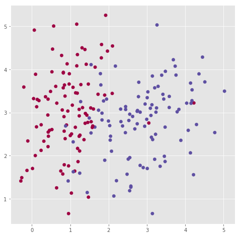

```python
# Visualize the data:
fig, ax = plt.subplots(figsize=(8,8))
plt.scatter(X[0, :], X[1, :], c=y, s=40, cmap=plt.cm.Spectral);
```

```python
# data shapes
print("X_train: {}".format(X_train.shape))
print("X_test: {}".format(X_test.shape))
print("y_train: {}".format(y_train.shape))
print("y_test: {}".format(y_test.shape))
```

```
X_train: (2, 180)
X_test: (2, 20)
y_train: (1, 180)
y_test: (1, 20)
```

The dataset consists of 200 records (180 are used in the training set). Each record belongs to a class (0 or 1). A logistic regression model is training on the data.

An important step of the analysis consists of understanding the distribution of the data across the various classes. The distribution establish a benchmark accuracy for our model. For instance, if our data is evenly distributed between two classes then our benchmark value (accuracy from a dummy classifier) will be 50%. But if our data was unevenly distributed 90%/10% then the benchmark would be defined as 90%.

```python
# data distribution
unique_elements, counts_elements = np.unique(y, return_counts=True)
print("Frequency of unique values of y:")
print(np.asarray((unique_elements, counts_elements)))

unique_elements, counts_elements = np.unique(y_train, return_counts=True)
print("\nFrequency of unique values of y_train:")
print(np.asarray((unique_elements, counts_elements)))

unique_elements, counts_elements = np.unique(y_test, return_counts=True)
print("\nFrequency of unique values of y_test:")
print(np.asarray((unique_elements, counts_elements)))
```

```
Frequency of unique values of y:
[[  0   1]
 [ 99 101]]

Frequency of unique values of y_train:
[[ 0  1]
 [89 91]]

Frequency of unique values of y_test:
[[ 0  1]
 [10 10]]
```

From the matrices above, the data appears evenly distributed for all sets (full, train, and test).

## 4. Simple Logistic Regression

```python
d = model(X_train, y_train, X_test, y_test, num_iterations = 2000, learning_rate = 0.5, print_cost = True)
```

```
Cost after iteration 0: 0.693147
Cost after iteration 100: 0.287603
Cost after iteration 200: 0.281655
Cost after iteration 300: 0.279128
Cost after iteration 400: 0.277851
Cost after iteration 500: 0.277187
Cost after iteration 600: 0.276836
Cost after iteration 700: 0.276647
Cost after iteration 800: 0.276546
Cost after iteration 900: 0.276490
Cost after iteration 1000: 0.276460
Cost after iteration 1100: 0.276443
Cost after iteration 1200: 0.276434
Cost after iteration 1300: 0.276428
Cost after iteration 1400: 0.276426
Cost after iteration 1500: 0.276424
Cost after iteration 1600: 0.276423
Cost after iteration 1700: 0.276423
Cost after iteration 1800: 0.276422
Cost after iteration 1900: 0.276422
train accuracy: 90.56 %
test accuracy: 95.00 %
```

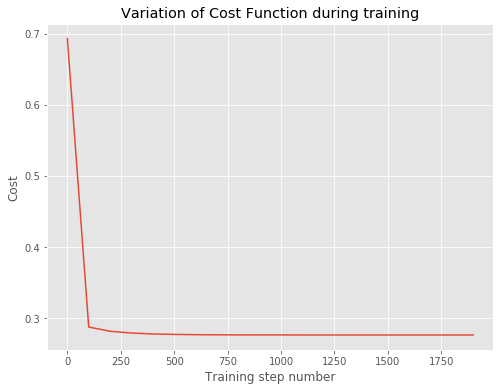

```python
# Visualize the data:
fig, ax = plt.subplots(figsize=(8,6))
ax.plot(list(range(0,2000,100)), d['costs'])
ax.set_title("Variation of Cost Function during training")
ax.set_xlabel('Training step number')
ax.set_ylabel('Cost');
```

```
Accuracy Training = 0.91
```

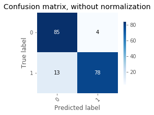

```python
TAD_tools.plot_confusion_matrix(y_train.T, predict(d['w'], d['b'], X_train).T,
                                classes=np.array([str(x) for x in range(2)]),
                                normalize=False,title=None,cmap=plt.cm.Blues)
print("Accuracy Training = {:.2f}".format(accuracy_score(y_train.T,  predict(d['w'], d['b'], X_train).T)));
```

```
Accuracy Testing = 0.95
```

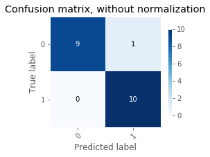

```python
TAD_tools.plot_confusion_matrix(y_test.T, predict(d['w'], d['b'], X_test).T,
                                classes=np.array([str(x) for x in range(2)]),
                                normalize=False,title=None,cmap=plt.cm.Blues)
print("Accuracy Testing = {:.2f}".format(accuracy_score(y_test.T,  predict(d['w'], d['b'], X_test).T)));
```

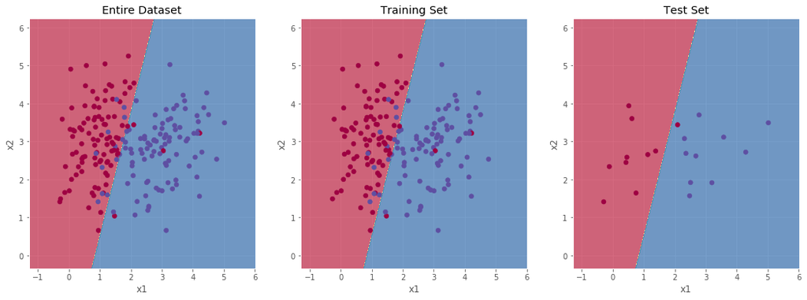

```python
TAD_tools.plot_decision_boundary_train_test(lambda x: predict(d['w'], d['b'], x.T),
                                            X_train, y_train.T.ravel(),
                                            X_test, y_test.T.ravel())
```

As shown by the accuracies computed above and the decision boundary plot, the logistic regression performs relatively well

```python
n_samples = 300
outliers_fraction = 0.15
n_outliers = int(outliers_fraction * n_samples)
n_inliers = n_samples - n_outliers
```

```python
blobs_params = dict(random_state=0, n_samples=n_inliers, n_features=2)
datasets = [
    make_blobs(centers=[[0, 0], [0, 0]], cluster_std=0.3,
               **blobs_params),
    make_circles(n_samples=400, factor=.3, noise=.05, random_state=10),
    make_blobs(centers=[[1, 1], [0, 0]], cluster_std=[0.7, 2.0],
               **blobs_params),
    make_moons(n_samples=n_samples, noise=.05, random_state=0)]
```

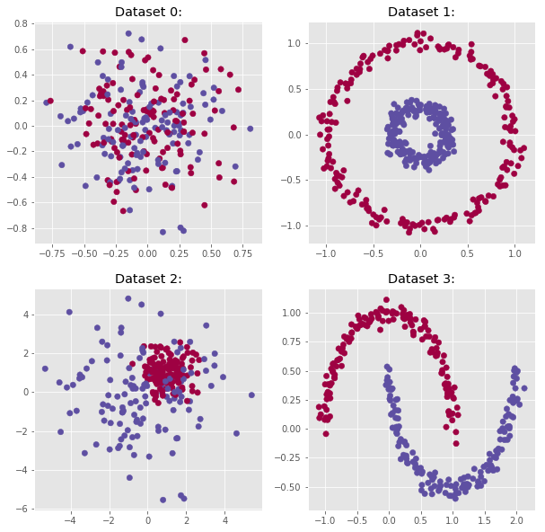

```python
# Visualize the data:
fig, axs = plt.subplots(2, 2, figsize=(10,10))

for row in range(2):
    for col in range(2):
        axs[row,col].scatter(datasets[2*row+col][0][:, 0],
                             datasets[2*row+col][0][:, 1],
                             c=datasets[2*row+col][1],
                             s=40,
                             cmap=plt.cm.Spectral)
        axs[row,col].set_title("Dataset {}:".format(2*row+col));
```

```
Dataset 0:
train accuracy: 55.90 %
test accuracy: 30.77 %

Dataset 1:
train accuracy: 31.11 %
test accuracy: 37.50 %

Dataset 2:
train accuracy: 79.04 %
test accuracy: 57.69 %

Dataset 3:
train accuracy: 88.52 %
test accuracy: 86.67 %
```

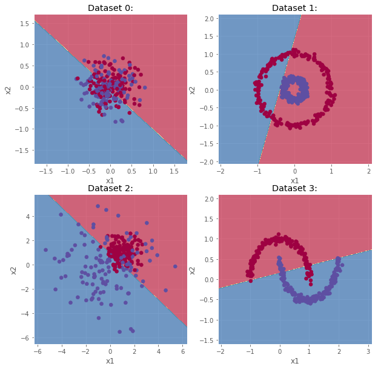

```python
fig, axs = plt.subplots(2,2,figsize=(10,10))

for i, dataset in enumerate(datasets):
    row = i//2
    col = i%2

    X = dataset[0]
    y = dataset[1]

    X_train, X_test, y_train, y_test = train_test_split(X, y, test_size=0.10, random_state=30)

    X, y = X.T, y.T
    X_train, X_test = X_train.T, X_test.T
    y_train, y_test = y_train.T.reshape(1,-1), y_test.T.reshape(1,-1)

    print("\nDataset {}:".format(i))
    d = model(X_train, y_train, X_test, y_test, num_iterations = 2000, learning_rate = 0.5, print_cost = False)

    TAD_tools.plot_decision_boundary(lambda x: predict(d['w'], d['b'], x.T), X, y, title="Dataset {}:".format(i),ax=axs[row,col])
```

## 5. Conclusion

### Pros

1. Simple to implement.
2. Few hyperparameters.
3. Easy to interprete and visualize (up to three dimensions).
4. Works for both binary and multi-class classification.
5. Can be upgraded with regularization (Ridge or Lasso)

### Cons

1. Works well if data relationships are linear.
2. Too simple to capture complex relationships.

In conclusion, a logistic regression can be seen as the first step of the path to a more complex model. It is often use as a mean to assess the complexity of a problem and obtain quick and rough results.